# Lab 3 Tasks 1-6 Markdown

Nico Wisebaker

2024-02-05

# Tasks

Lab 3 Tasks

## Task 1

```r
getwd()
```

```
## [1] "C:/Users/nico/Documents/MATH 4753/Labs/Lab 3"
```

## Task 2

```r
spruce <- read.csv("SPRUCE.csv")
head(spruce)
```

```
##   BHDiameter Height
## 1       18.9   20.0
## 2       16.6   18.8
## 3       15.5   16.8
## 4       15.5   16.9
## 5       19.4   20.2
## 6       13.7   16.3
```

Read in SPRUCE.csv and created mylab3.R

## Task 3

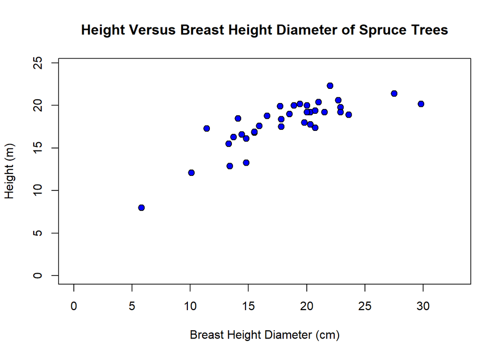

```r
bhdiameter <- spruce$BHDiameter
height <- spruce$Height
scatter <- plot(bhdiameter, height,
      main = "Height Versus Breast Height Diameter of Spruce Trees",
      ylab = "Height (m)",
      xlab = "Breast Height Diameter (cm)",
      pch = 21, bg = "Blue", cex = 1.2,
      xlim = c(0, 1.1*max(bhdiameter)),
      ylim = c(0, 1.1*max(height)))
```

```r
scatter
```

The data does not seem to have a straight line relationship. We *could* use one to describe it somewhat accurately but it seems more logarithmic than linear.

```r
library(s20x)

layout(matrix(1:3, nr = 3))
trend1 <- trendscatter(Height ~ BHDiameter, f = 0.5, data = spruce)
trend2 <- trendscatter(Height ~ BHDiameter, f = 0.6, data = spruce)
trend3 <- trendscatter(Height ~ BHDiameter, f = 0.7, data = spruce)
```

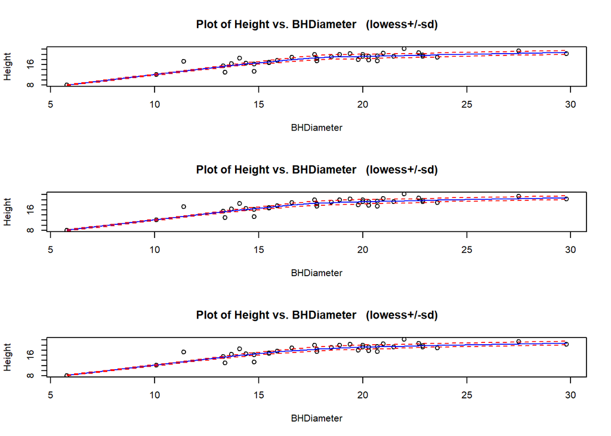

Lowess smoother scatter plots, formatted with layout()

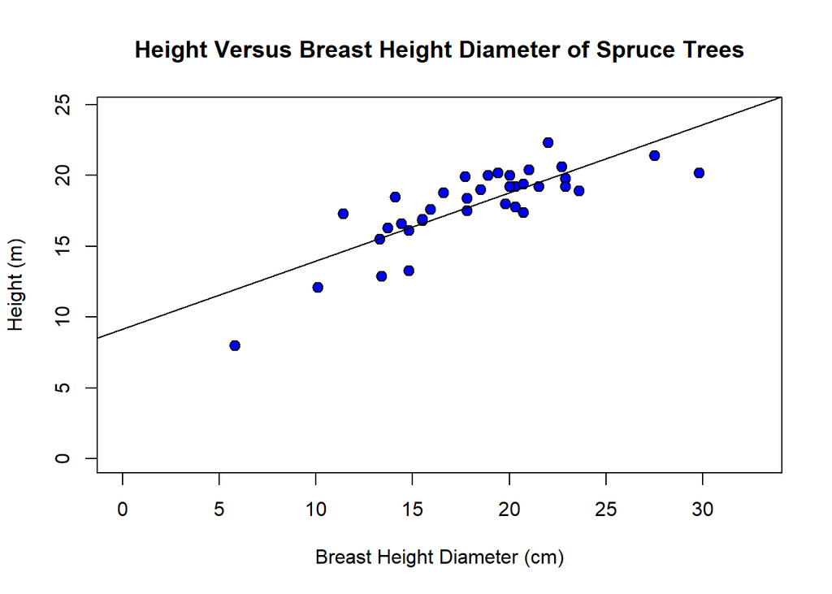

```r
spruce.lm <- with(spruce, lm(height ~ bhdiameter))
plot(bhdiameter, height,
      main = "Height Versus Breast Height Diameter of Spruce Trees",
      ylab = "Height (m)",
      xlab = "Breast Height Diameter (cm)",
      pch = 21, bg = "Blue", cex = 1.2,
      xlim = c(0, 1.1*max(bhdiameter)),
      ylim = c(0, 1.1*max(height)))
abline(spruce.lm)
```

abline (least squares) plot. This linear model seems accurate enough, although the points further from the rest of the data stray more from the line. The trendscatter plots suggest the data is a little curvy.

## Task 4

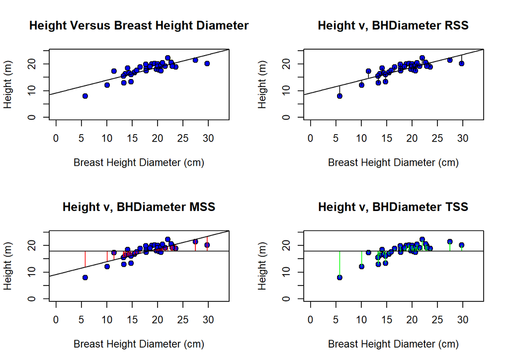

```r
layout <- layout(matrix(1:4, nr = 2, nc = 2, byrow = TRUE))

plot(bhdiameter, height,
      main = "Height Versus Breast Height Diameter",
      ylab = "Height (m)",
      xlab = "Breast Height Diameter (cm)",
      pch = 21, bg = "Blue", cex = 1.2,
      xlim = c(0, 1.1*max(bhdiameter)),
      ylim = c(0, 1.1*max(height)))
abline(spruce.lm)

plot(bhdiameter, height,
      main = "Height v, BHDiameter RSS",
      ylab = "Height (m)",
      xlab = "Breast Height Diameter (cm)",
      pch = 21, bg = "Blue", cex = 1.2,
      xlim = c(0, 1.1*max(bhdiameter)),
      ylim = c(0, 1.1*max(height)))
resid <- with(spruce,predict(spruce.lm, data.frame(bhdiameter)))
with(spruce,{segments(bhdiameter, height, bhdiameter, resid)})
abline(spruce.lm)

plot(bhdiameter, height,
      main = "Height v, BHDiameter MSS",
      ylab = "Height (m)",
      xlab = "Breast Height Diameter (cm)",
      pch = 21, bg = "Blue", cex = 1.2,
      xlim = c(0, 1.1*max(bhdiameter)),
      ylim = c(0, 1.1*max(height)))
with(spruce, segments(bhdiameter, mean(height), bhdiameter, resid,col = "Red"))
abline(spruce.lm)
abline(h = mean(height))

plot(bhdiameter, height,
      main = "Height v, BHDiameter TSS",
      ylab = "Height (m)",
      xlab = "Breast Height Diameter (cm)",
      pch = 21, bg = "Blue", cex = 1.2,
      xlim = c(0, 1.1*max(bhdiameter)),
      ylim = c(0, 1.1*max(height)))
with(spruce, segments(bhdiameter, mean(height), bhdiameter, height, col = "Green"))
abline(h = mean(height))
```

Linear regression plot, residual sum of squares (RSS) plot, mean sum of squares (MSS) plot, and total sum of squares (TSS plot.

```r
RSS <- with(spruce, sum((height - resid)^2))
RSS
```

```
## [1] 95.70281
```

```r
MSS <- with(spruce, sum((resid - mean(height))^2))
MSS
```

```
## [1] 183.2447
```

```r
TSS <- with(spruce, sum((height - mean(height))^2))
TSS
```

```
## [1] 278.9475
```

```r
MSS/TSS
```

```
## [1] 0.6569146
```

calculated rss mss tss, and mss/tss is r^2, the proportion of variance in the dependent variable explained by the independent variable

```r
RSS + MSS == TSS
```

```
## [1] FALSE
```

```r
RSS + MSS
```

```
## [1] 278.9475
```

```r
TSS
```

```
## [1] 278.9475
```

R claims they are not equal, but the values are equal– at least to the 4th decimal place.

## Task 5

```r
summary(spruce.lm)
```

```
##
## Call:
## lm(formula = height ~ bhdiameter)
##
## Residuals:
##     Min      1Q  Median      3Q     Max
## -3.9394 -0.9763  0.2829  0.9950  2.6644
##
## Coefficients:
##             Estimate Std. Error t value Pr(>|t|)
## (Intercept)  9.14684    1.12131   8.157 1.63e-09 ***
## bhdiameter   0.48147    0.05967   8.069 2.09e-09 ***
## ---
## Signif. codes:  0 '***' 0.001 '**' 0.01 '*' 0.05 '.' 0.1 ' ' 1
##
## Residual standard error: 1.678 on 34 degrees of freedom
## Multiple R-squared:  0.6569, Adjusted R-squared:  0.6468
## F-statistic:  65.1 on 1 and 34 DF,  p-value: 2.089e-09
```

Value of slope 0.48147 Value of intercept 9.14684 Equation of fitted line ŷ = 9.14684 + 0.48147x

```r
predict(spruce.lm, bhdiameter = 15)
```

```
##        1        2        3        4        5        6        7        8
## 18.24670 17.13931 16.60969 16.60969 18.48744 15.74304 18.77632 22.38738
##        9       10       11       12       13       14       15       16
## 23.49477 18.92077 18.68003 20.17260 18.92077 15.93563 18.77632 14.00973
##       17       18       19       20       21       22       23       24
## 19.73927 11.93939 20.50963 19.11336 16.27266 17.71708 20.07630 14.63565
##       25       26       27       28       29       30       31       32
## 18.05411 16.08007 19.49854 15.59859 16.27266 17.71708 17.66893 19.11336
##       33       34       35       36
## 19.25780 15.55045 16.80228 20.17260
```

```r
predict(spruce.lm, bhdiameter = 18)
```

```
##        1        2        3        4        5        6        7        8
## 18.24670 17.13931 16.60969 16.60969 18.48744 15.74304 18.77632 22.38738
##        9       10       11       12       13       14       15       16
## 23.49477 18.92077 18.68003 20.17260 18.92077 15.93563 18.77632 14.00973
##       17       18       19       20       21       22       23       24
## 19.73927 11.93939 20.50963 19.11336 16.27266 17.71708 20.07630 14.63565
##       25       26       27       28       29       30       31       32
## 18.05411 16.08007 19.49854 15.59859 16.27266 17.71708 17.66893 19.11336
##       33       34       35       36
## 19.25780 15.55045 16.80228 20.17260
```

```r
predict(spruce.lm, bhdiameter = 20)
```

```
##        1        2        3        4        5        6        7        8
## 18.24670 17.13931 16.60969 16.60969 18.48744 15.74304 18.77632 22.38738
##        9       10       11       12       13       14       15       16
## 23.49477 18.92077 18.68003 20.17260 18.92077 15.93563 18.77632 14.00973
##       17       18       19       20       21       22       23       24
## 19.73927 11.93939 20.50963 19.11336 16.27266 17.71708 20.07630 14.63565
##       25       26       27       28       29       30       31       32
## 18.05411 16.08007 19.49854 15.59859 16.27266 17.71708 17.66893 19.11336
##       33       34       35       36
## 19.25780 15.55045 16.80228 20.17260
```

## Task 6

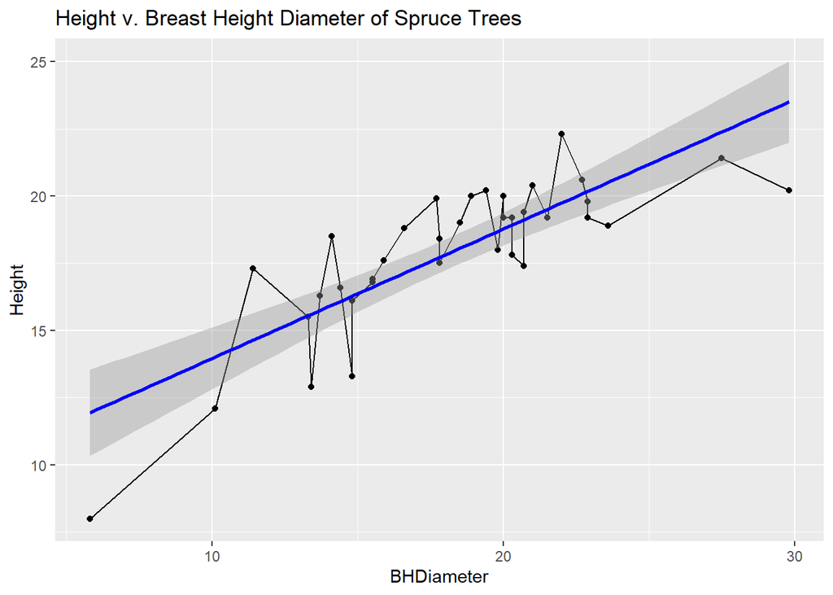

```r
library(ggplot2)
g=ggplot(spruce, aes(x=BHDiameter,y=Height))
g=g+geom_point() + geom_line()+ geom_smooth(method="lm", color = "Blue")
g+ggtitle("Height v. Breast Height Diameter of Spruce Trees")
```

## Task 7

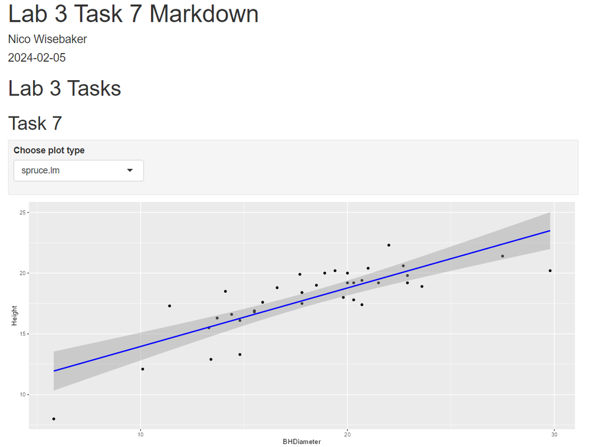

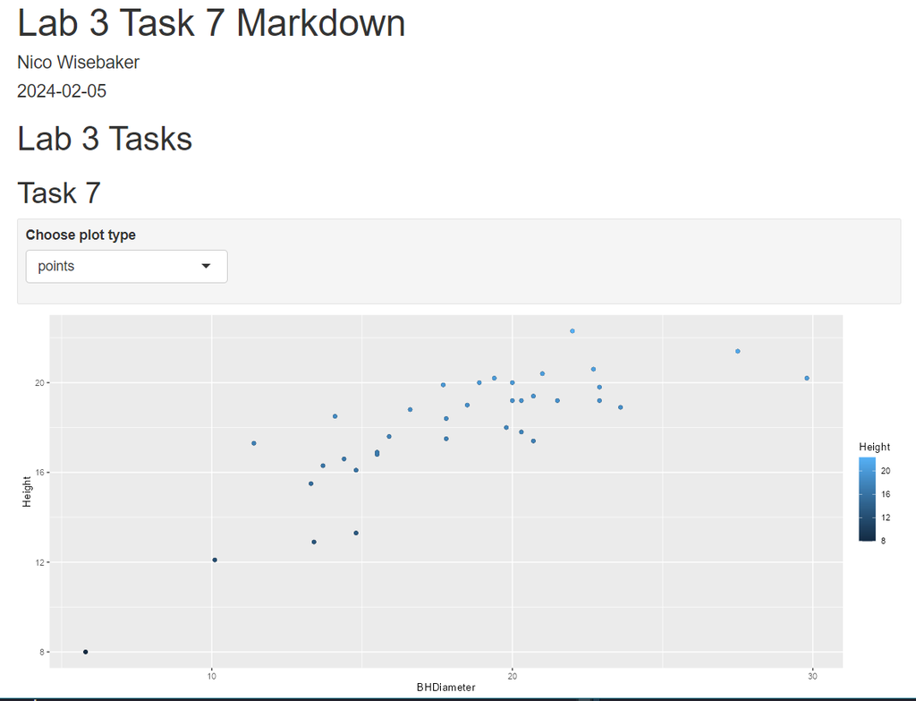

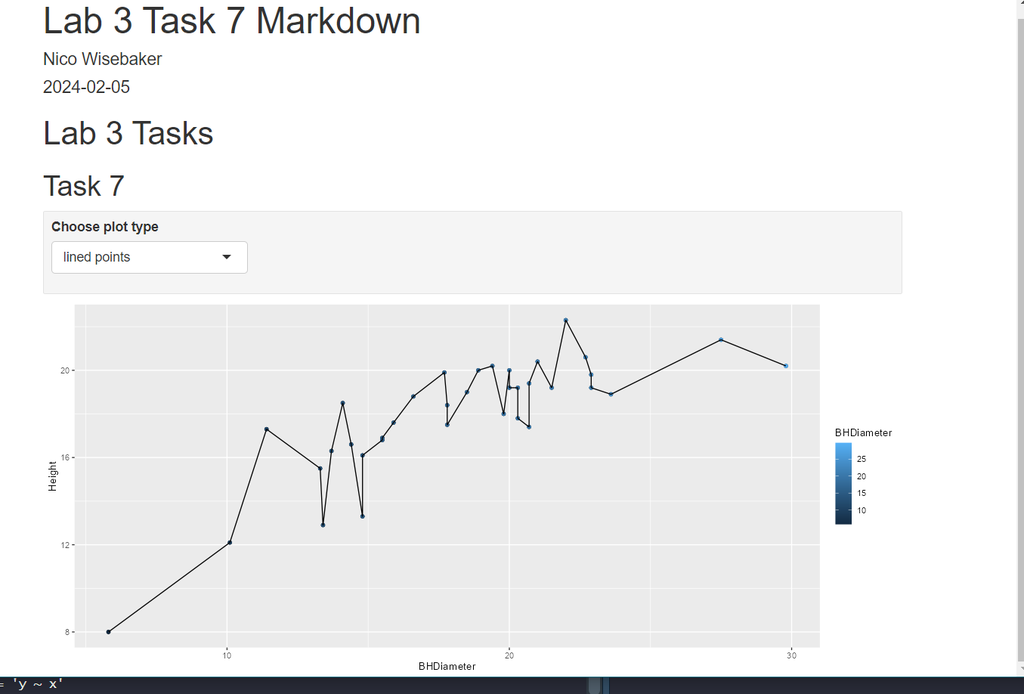